# 为什么lasso有变量选择功能而ridge没有？

林荟

林荟 (Hui Lin)

2016-9-11

文中的代码可重复：），有任何问题联系邮箱: *<longqiman>@gmail.com*

对模型参数进行限制或者规范化能将一些参数估计朝着0收缩。使用收缩方法提高模型拟合表现的原理可能不那么显而易见，但是收缩方法的效果是非常好的，这也是我最常使用的方法，尤其是项目要求使用可以解释的模型时。岭回归（ridge regression）、lasso以及弹性网络（elastic net）。弹性网络结合了ridge和lasso中的罚函数，可以说是它们的一般化版本。

ridge是在结构风险最小化的正则化因子上使用模型参数向量的二阶范数形式，lasso使用的是一阶范数形式。虽然ridge可以将参数估计值向0进行收缩，但对于任何调优参数值，它都不能将系数取值变为严格的0。尽管某些参数估计值变得非常小以至于可以忽略，但事实上ridge并没有进行变量选择。这可能对预测精确度来说不是问题，但却对模型解释提出了挑战，尤其在变量个数大的时候。一种流行的用来替代ridge的模型是“最小绝对收缩与选择算子”模型，通常被称为lasso。lasso不仅将参数估计向0收缩，当调优参数足够大时，一些参数估计将直接缩减为零，这可以达到特征提取的作用。这样一来，lasso回归的结果更易于解释。

可能有人会问从ridge到lasso，只是罚函数从二阶范数变成一阶范数，为什么lasso就能够将参数估计收缩成0而ridge不能呢？要回答这个问题，我们先看下lasso和ridge分别对应的另一版本的等价优化方程。对于lasso而言，优化下面两个方程是等价的：

$$\Sigma_{i=1}^{n}(y_{i}-\beta_{0}-\Sigma_{j=1}^{p}\beta_{j}x_{ij})^{2}+\lambda\Sigma_{j=1}^{p}|\beta_{j}|=RSS+\lambda\Sigma_{j=1}^{p}|\beta_{j}|$$

$$\underset{\beta}{min}\left\{ \Sigma_{i=1}^{n}\left(y_{i}-\beta_{0}-\Sigma_{j=1}^{p}\beta_{j}x_{ij}\right)^{2}\right\} ,\ \Sigma_{j=1}^{p}|\beta_{j}|\leq s$$

也就是说，对每个调优参数$\lambda$的取值，都存在相应的$s$值，使得上面两个方程优化后得到的参数估计相同。类似的，对于ridge，下面两个方程等价：

$$\Sigma_{i=1}^{n}(y_{i}-\beta_{0}-\Sigma_{j=1}^{p}\beta_{j}x_{ij})^{2}+\lambda\Sigma_{j=1}^{p}\beta_{j}^{2}=RSS+\lambda\Sigma_{j=1}^{p}\beta_{j}^{2}$$

$$\underset{\beta}{min}\left\{ \Sigma_{i=1}^{n}\left(y_{i}-\beta_{0}-\Sigma_{j=1}^{p}\beta_{j}x_{ij}\right)^{2}\right\} ,\ \Sigma_{j=1}^{p}\beta_{j}^{2}\leq s$$

当p＝2时，lasso的参数估计是所有满足$|\beta_{1}|+|\beta_{2}|\leq s$的$\beta_{1}$和$\beta_{2}$取值中最小化$RSS$的。ridge是估计所有满足$\beta_{1}^{2}+\beta_{2}^{2}\leq s$的参数取值中最小化$RSS$的。当s很大时，相应的限制条件几乎是无效的，只要参数估计能够最小化$RSS$即使绝对值很大也没有问题。只要s所定义的区域包含最小二乘解，那么收缩方法得出的参数估计和一般最小二乘回归就相同。相反，如果s很小，那么可能的参数取值范围就很有限。

了解这样的等价表达之后，我们再看看ridge和lasso的不同之处。

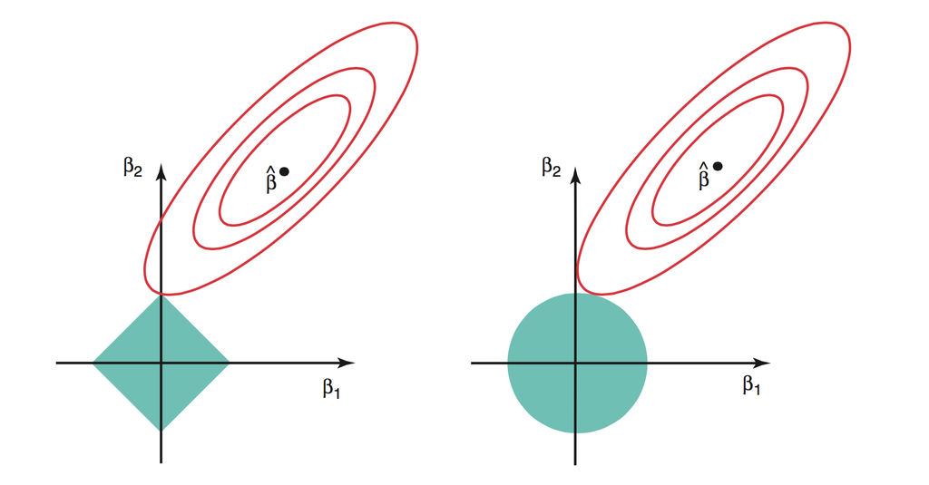

左边是lasso对应的误差等位线和正方形限制区域，右边是ridge对应的等位线和圆形限制区域。 上面图中围绕在$\hat{\beta}$周围的椭圆表示有相同RSS的参数估计。随着椭圆的扩大，对应的RSS增加。lasso和ridge的估计值就是在一定的限制区域下，椭圆不断扩张的过程中和限制区域的第一个接触点。大家想想看，如果有某个参数的估计是0的话，那么这个接触点该在哪里？一定在某条坐标轴上。由于ridge的限制区域是圆形，所以真正的触点无法落在坐标轴上，可能无限接近，但就是到不了。这就是求之而不可得的数学诠释。所以ridge无法将参数收缩成0，而lasso可以。

上面是2个参数的情况。如果参数个数是3的话，那么lasso的限制区域就是一个三位空间的多面体，而ridge的限制区域就是个球。参数个数再增加的话，就得让科幻小说家来描述了。希望大家理解lasso可以进行变量选择，而ridge不行的几何解释。